# Unscheduled R Practice - Part 1

Unscheduled R Practice - Part 1 Jason Chhay 10/11/2020

#### [Back to projects page](https://jwchhay.github.io/projects.html)

## Documentation and Creating Random Projects

This is just a simple thing I wanted to try: documenting my thought process when working on something. For this, I want to just look at some basketball stats. I am going to use https://www.basketball-reference.com/leagues/NBA_stats_per_game.html and try scraping some information and maybe plot some things. I’ll show my code doing this process.

### Scraping and Cleaning

```r
# Essentially, I just look at a website which has a table and I
# try to extract the information from there.
# The package I use can easily extract HTML tables, but
# this website doesn't have them I think.
# This thought process can be applied to practically any website that has
# data on it, but I'll just work with a table for now since it's easily
# observable.

# website to scrape
website <- "https://www.basketball-reference.com/leagues/NBA_stats_per_game.html"

# Find elements in page I want to extract, and turn it into something that we
# can manipulate. I'm just trying to extract the data off the website and place it
# into R.
pattern <- "#stats a , .right , .center"
league_avg <- website %>% read_html() %>%
           html_nodes(pattern) %>% html_text()

# league_avg is a character vector that's essentially a vector with a bunch of data
# the goal is to convert it into a data frame, a data structure that makes a lot more sense

league_average <- league_avg # copy of vector so i don't have to keep requesting info from the website

# I just want to look at the seasons where the three-point line was used, aka starting at 1979-80
match(42, league_average) # 1421 is when a new row starts, so keep everything before this
```

```
## [1] 1421
```

```r
league_average <- league_average[1:1420]
head(league_average)
```

```
## [1] ""         "Per Game" "Shooting" "Advanced" "Rk"       "Season"
```

So since the original table has this “[1]”" “Per Game” “Shooting” “Advanced”" overhead portion that I don’t need, I’m going to remove it. It appears three times, so I am going to try removing any instance of these terms instead of manually finding them in the vector.

```r
remove_pattern <- league_average[1:4] # it's the first four terms of the vector

# got the nest idea from the following link (I like using stackoverflow for these kind of scenarios):
# https://stackoverflow.com/questions/5577727/is-there-an-r-function-for-finding-the-index-of-an-element-in-a-vector
which(league_average %in% remove_pattern)
```

```
##  [1]    1    2    3    4  677  678  679  680 1353 1354 1355 1356
```

Based on this vector, we indeed see three groupings of consecutive numbers with the pattern in the original vector. After removing it, I should be able to properly format the table.

```r
league_average <- league_average[-which(league_average %in% remove_pattern)]
# keep elements besides those found in the previous vector
head(league_average)
```

```
## [1] "Rk"     "Season" "Lg"     "Age"    "Ht"     "Wt"
```

```r
which(league_average %in% remove_pattern) # confirming we removed those words from the vector
```

```
## integer(0)
```

### More Cleaning

Alright, we removed the words. Now, if we look at the first row in the table on the website, it should just be the column names. However, this also appears three times. I want to keep only the first one, so I’m going to remove the two latter ones. I realize now that I could’ve removed them at the same time as the overhead names, but it didn’t occur to me.

```r
which(league_average %in% "ORtg") # so this tells us that there are 32 columns.
```

```
## [1]   32  704 1376
```

```r
league_average <- league_average[-c(((704-31):704),((1376-31):1376))] # really ugly looking way to say "remove the two latter rows"
which(league_average %in% c("Rk","ORtg")) # confirm we removed the other instances of the rows
```

```
## [1]  1 32
```

Okay, now the table is formatted the way I want. Time to convert it into a data frame. I needed to brush up a bit on some R fundamentals, so I checked online for a quick refresher from https://www.reddit.com/r/rprogramming/comments/b31neu/transform_a_vector_of_1184_entries_into_a_data/

```r
league_df <- matrix(league_average, ncol = 32, byrow = TRUE)
league_df <- as.data.frame(league_df, stringsAsFactors = FALSE)

league_df[1:6,1:10] # previewing the data frame
```

```
##   V1      V2  V3   V4  V5  V6   V7    V8   V9  V10
## 1 Rk  Season  Lg  Age  Ht  Wt    G    MP   FG  FGA
## 2  1 2019-20 NBA 26.1 6-6 218 1059 241.8 40.9 88.8
## 3  2 2018-19 NBA 26.3 6-6 219 1230 241.6 41.1 89.2
## 4  3 2017-18 NBA 26.4 6-7 220 1230 241.4 39.6 86.1
## 5  4 2016-17 NBA 26.6 6-7 221 1230 241.6 39.0 85.4
## 6  5 2015-16 NBA 26.7 6-7 222 1230 241.8 38.2 84.6
```

```r
# some issues with colnames and rownames

colnames(league_df) <- league_df[1,1:32]
league_df <- league_df[-1,]
rownames(league_df) <- league_df[1:41, 1]
league_df[1:6,1:10]
```

```
##   Rk  Season  Lg  Age  Ht  Wt    G    MP   FG  FGA
## 1  1 2019-20 NBA 26.1 6-6 218 1059 241.8 40.9 88.8
## 2  2 2018-19 NBA 26.3 6-6 219 1230 241.6 41.1 89.2
## 3  3 2017-18 NBA 26.4 6-7 220 1230 241.4 39.6 86.1
## 4  4 2016-17 NBA 26.6 6-7 221 1230 241.6 39.0 85.4
## 5  5 2015-16 NBA 26.7 6-7 222 1230 241.8 38.2 84.6
## 6  6 2014-15 NBA 26.7 6-7 223 1230 242.0 37.5 83.6
```

Sadly the data.frame function converted all the columns as characters. I need to convert the classes because otherwise plotting some of the numbers gets out of control. Idea from https://stackoverflow.com/questions/32173557/how-to-transform-a-vector-into-data-frame-with-fixed-dimension

```r
str(league_df, list.len = 10) # just to show that things like "Age" is a character right now
```

```
## 'data.frame':    41 obs. of  32 variables:
##  $ Rk    : chr  "1" "2" "3" "4" ...
##  $ Season: chr  "2019-20" "2018-19" "2017-18" "2016-17" ...
##  $ Lg    : chr  "NBA" "NBA" "NBA" "NBA" ...
##  $ Age   : chr  "26.1" "26.3" "26.4" "26.6" ...
##  $ Ht    : chr  "6-6" "6-6" "6-7" "6-7" ...
##  $ Wt    : chr  "218" "219" "220" "221" ...
##  $ G     : chr  "1059" "1230" "1230" "1230" ...
##  $ MP    : chr  "241.8" "241.6" "241.4" "241.6" ...
##  $ FG    : chr  "40.9" "41.1" "39.6" "39.0" ...
##  $ FGA   : chr  "88.8" "89.2" "86.1" "85.4" ...
##   [list output truncated]
```

```r
league_df[] <- lapply(league_df, type.convert)
str(league_df, list.len = 10)
```

```
## 'data.frame':    41 obs. of  32 variables:
##  $ Rk    : int  1 2 3 4 5 6 7 8 9 10 ...
##  $ Season: Factor w/ 41 levels "1979-80","1980-81",..: 41 40 39 38 37 36 35 34 33 32 ...
##  $ Lg    : Factor w/ 1 level "NBA": 1 1 1 1 1 1 1 1 1 1 ...
##  $ Age   : num  26.1 26.3 26.4 26.6 26.7 26.7 26.5 26.7 26.6 26.6 ...
##  $ Ht    : Factor w/ 2 levels "6-6","6-7": 1 1 2 2 2 2 2 2 2 2 ...
##  $ Wt    : int  218 219 220 221 222 223 223 223 223 223 ...
##  $ G     : int  1059 1230 1230 1230 1230 1230 1230 1229 990 1230 ...
##  $ MP    : num  242 242 241 242 242 ...
##  $ FG    : num  40.9 41.1 39.6 39 38.2 37.5 37.7 37.1 36.5 37.2 ...
##  $ FGA   : num  88.8 89.2 86.1 85.4 84.6 83.6 83 82 81.4 81.2 ...
##   [list output truncated]
```

```r
# I'll remove factors from some columns as well.
# (https://stackoverflow.com/questions/2851015/convert-data-frame-columns-from-factors-to-characters)
league_df$Season <- sapply(league_df$Season, as.character)
league_df$Lg <- sapply(league_df$Lg, as.character)
league_df$Ht <- sapply(league_df$Ht, as.character)
```

Now it’s fixed. I’ve now cleaned up data that I scraped from the website. I haven’t played around with basketball-reference.com enough to see if I download the table in some form, but this is just one way I’ve been able to extract data manually.

### Even More Cleaning

I just realized that some column names have special characters and numbers in it, which makes it really difficult to manipulate the columns. They mess up certain functions, so I need to change them first. Idea from https://stackoverflow.com/questions/12995440/any-way-to-edit-values-in-a-matrix-in-r and https://stackoverflow.com/questions/3423085/numbers-as-column-names-of-data-frames.

```r
x <- colnames(league_df)
x # to show that there are percent symbols
```

```
##  [1] "Rk"     "Season" "Lg"     "Age"    "Ht"     "Wt"     "G"      "MP"
##  [9] "FG"     "FGA"    "3P"     "3PA"    "FT"     "FTA"    "ORB"    "DRB"
## [17] "TRB"    "AST"    "STL"    "BLK"    "TOV"    "PF"     "PTS"    "FG%"
## [25] "3P%"    "FT%"    "Pace"   "eFG%"   "TOV%"   "ORB%"   "FT/FGA" "ORtg"
```

```r
x <- gsub("%", "Percent", x)
x <- gsub("3P", "ThreePoint", x)
x <- gsub("/", "Over", x)
x # now it's cleaned up
```

```
##  [1] "Rk"                "Season"            "Lg"
##  [4] "Age"               "Ht"                "Wt"
##  [7] "G"                 "MP"                "FG"
## [10] "FGA"               "ThreePoint"        "ThreePointA"
## [13] "FT"                "FTA"               "ORB"
## [16] "DRB"               "TRB"               "AST"
## [19] "STL"               "BLK"               "TOV"
## [22] "PF"                "PTS"               "FGPercent"
## [25] "ThreePointPercent" "FTPercent"         "Pace"
## [28] "eFGPercent"        "TOVPercent"        "ORBPercent"
## [31] "FTOverFGA"         "ORtg"
```

```r
colnames(league_df) <- x
```

### Plotting

Finally I can plot things easily now. For example, 3 pointers attempted throughout the years. This doesn’t require any of the columns that need perecentages, but I think it’s good practice to not have special characters in column names.

Here’s an example I wanted to show off: average number of threes attempted per game throughout the history of the three point line.

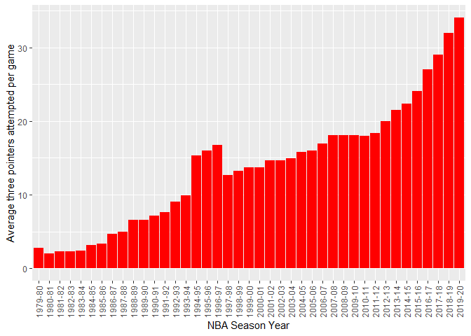

```r
# https://stackoverflow.com/questions/1330989/rotating-and-spacing-axis-labels-in-ggplot2
ggplot(data = league_df, aes(x = Season, y = ThreePointA)) +
  geom_bar(stat = "identity", fill = "red") +
  theme(axis.text.x = element_text(angle = 90, vjust = 0.5, hjust = 1)) +
  xlab("NBA Season Year") +
  ylab("Average three pointers attempted per game")
```

Upon looking at this, you can see a trend in more threes being shot. They are just more efficient than taking a regular 2 point shot, since you literally earn another extra point just from shooting further away. Why the little spike from 1994 to 1997? The NBA shortened the three point line during those years (https://www.cbssports.com/nba/news/what-the-shortened-nba-3-point-line-of-the-mid-1990s-says-about-the-future-of-long-range-shooting/), so teams attempted more to capitalize on the shortened distance. There’s your trivia for the day.

### Conclusive Thoughts

This was just an example of how I might analyzing something on a website. It probably isn’t the best way to do it, as I’d have to research what the proper method would be, but it works. Also, it’s pretty funny how most of my work was just to clean data.

Cheers.